# HW4 CS625

Sujitha Cherukuthota

# Dataset - 1

# Dataset Cleaning

I did my dataset set cleaning using Open refine and I also did manually for some changes. The columns which contains strings are converted into numeric format. I also removed the unwanted characters from the dataset. After cleaning the dataste and mnually editing I saved it as a CSV file.

## Question 1

**Q1: Compare the ages of women at the time of the birth of their first child between 1990-2008. For instance, is there any evidence that women in the US are waiting longer to have their first child?**

ANS: I did two charts for this question one is line graph and other one is mutiple line graph. I created both graphs to understand crealy. Line graph actually shows the change in time period I think this line graph is beat choice for this question to show the time period change.

’’’ # Plotting

plt.figure(figsize=(12, 6)) sns.lineplot(x=average_age_first_birth.index, y=average_age_first_birth.values, marker=‘o’, label=‘Average Age at First Childbirth’) for age_group in total_births_by_age_group.index: sns.lineplot(x=total_births_by_age_group.columns, y=total_births_by_age_group.loc
$$age_group$$
, marker=‘o’, label=f’Total {age_group}’)

plt.xlabel(‘Year’) plt.ylabel(‘Count’) plt.title(‘Comparison of Average Age at First Childbirth and Total Births by Age Group (1990-2008)’) plt.legend(title=‘Age Group’) plt.grid(True) plt.show()

’’’

**1st Graph**

**2nd Graph**

Idiom: Multiple Line Chart / Mark: Line | Data: Attribute | Data: Attribute Type | Encode: Channel | | — |—| — | | Count | value, quantitative | vertical spatial region (y-axis) | | Year | value, Temporal | horizontal position on a common scale (x-axis) | | Count |value, categorical |

[figure not shown]

[figure not shown]

## Question 2

**How does this compare to the number of women in each age group who had a child (not necessarily their first) in that year? What does this say about the age of women giving birth in the US?**

’’’ **Plotting the comparison** plt.figure(figsize=(10, 6)) plt.plot(data[‘Age of mother’], data[‘1990_First_Births’], marker=‘o’, label=‘Average Age at First Childbirth’, color=‘b’) plt.bar(data[‘Age of mother’], data[‘1990_Total_Births’], alpha=0.5, label=‘Total Number of Women with Childbirth’, color=‘orange’)

plt.axhline(y=average_age_first_birth, color=‘r’, linestyle=‘–’, label=‘Average Age (1990)’) plt.xlabel(‘Age Group’) plt.ylabel(‘Number of Women / Average Age’) plt.title(‘Comparison of Average Age at First Childbirth and Total Number of Women with Childbirth (1990)’) plt.xticks(rotation=45) plt.legend() plt.tight_layout() plt.show() ’’’ Idiom: Multiple Line Chart / Mark: Line | Data: Attribute | Data: Attribute Type | Encode: Channel | | — |—| — | | Number of women/Average Age | value, quantitative | vertical spatial region (y-axis) | | Age Group| value, Temporal | horizontal position on a common scale (x-axis) | | Number of women/Average Age |value, categorical | Hue |

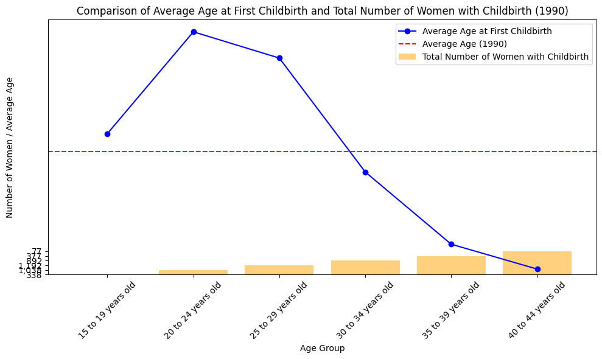

3

## Further Questions:

**What further questions does this prompt? What hypotheses do you have about what the answers might be? Are there other tables that might help you address these questions?**

ANS: Question: Are there regional disparities in the average age at first childbirth?

Due to factors such as education and career opportunities, regions with higher socioeconomic status may have a higher average age at first childbirth.

Question: How does educational attainment affect the average age at first childbirth?

Women with higher levels of education may postpone childbirth to pursue their careers or personal goals, resulting in a higher average age at first childbirth.

# Extra Credits

**Combine the data from Tables 91 and 92 (Women Who Have Had a Child in the Last Year By Selected Characteristics) to investigate other factors that affect this.**

ANS: We can investigate various factors such as education, marital status, ethnicity, and employment that influence when women choose to have children by combining data from Tables 91 and 92. Looking at these factors together helps us understand why women choose to have children. For example, we can investigate whether education level influences childbirth timing or employment status.

# Reference

https://seaborn.pydata.org/

Link to Python colab: https://colab.research.google.com/drive/1Bb9h0ew2kp5VStji5avP9OFULXlvDFQl?usp=sharing